# Practical Homework 2: Support Vector Classification

Let’s try higher degrees of polynomial.

```r
tune.out <- tune(svm, DIABETICEV ~SALADSNO+ VIG10DMIN+HINOTCOVE+HOURSWRK+EDUC , data = train, kernel = "polynomial", degree=3,
    ranges = list(cost = c(0.01, 0.05, 0.1, 1, 5, 10)))
```

```r
summary(tune.out)
```

```
##
## Parameter tuning of 'svm':
##
## - sampling method: 10-fold cross validation
##
## - best parameters:
##  cost
##    10
##
## - best performance: 0.356938
##
## - Detailed performance results:
##    cost     error dispersion
## 1  0.01 0.4947734 0.06355998
## 2  0.05 0.4577706 0.07017330
## 3  0.10 0.4426920 0.06852713
## 4  1.00 0.3998612 0.09915692
## 5  5.00 0.3590194 0.11302869
## 6 10.00 0.3569380 0.09424012
```

Let’s make our tuned model

```r
svmdiabetes_poly3<-svm(DIABETICEV ~SALADSNO+ VIG10DMIN+HINOTCOVE+HOURSWRK+EDUC, data=train, kernel="polynomial",degree=3, cost=10, scale=TRUE)
```

```r
pred_test<-predict(svmdiabetes_poly3 , test, type="response")
table(pred_test, test$DIABETICEV)
```

```
##
## pred_test   1   2
##         1 168 111
##         2  86 100
```

```r
t<-table(pred_test, test$DIABETICEV)
poly3_acc<-sum(diag(t))/sum(t)
sum(diag(t))/sum(t)
```

```
## [1] 0.5763441
```

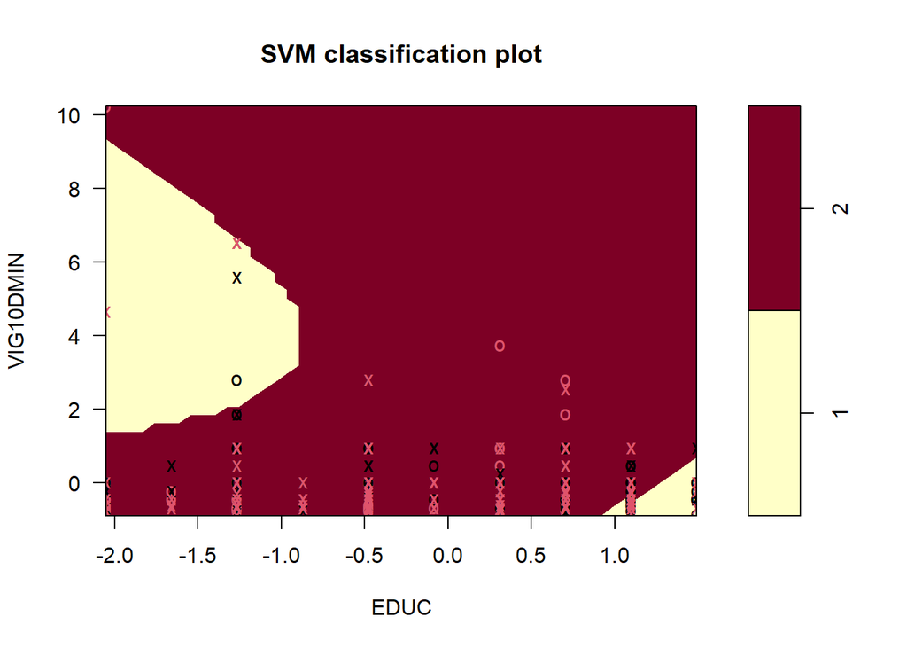

```r
plot(svmdiabetes_poly3, train, VIG10DMIN ~ EDUC)
```

We see that education might not affect diabetes levels too much. The two patches might represent those in more labor intensive jobs as well as intellectual job, both equipping individuals with tools to combat the development of diabetes.

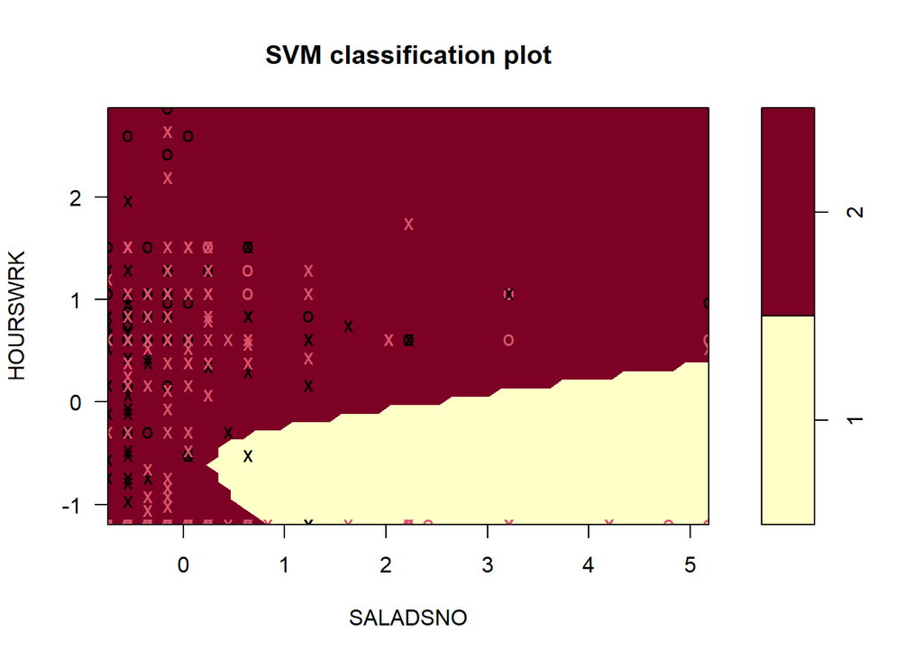

```r
plot(svmdiabetes_poly3, train, HOURSWRK ~ SALADSNO)
```

We see that having more salads and working less leads to less diabetes. This is rather confusing.

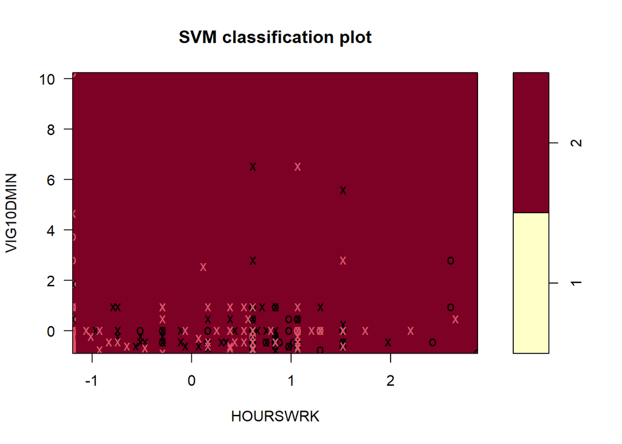

```r
plot(svmdiabetes_poly3, train, VIG10DMIN ~ HOURSWRK)
```

This is categorizing everyone as having diabetes.

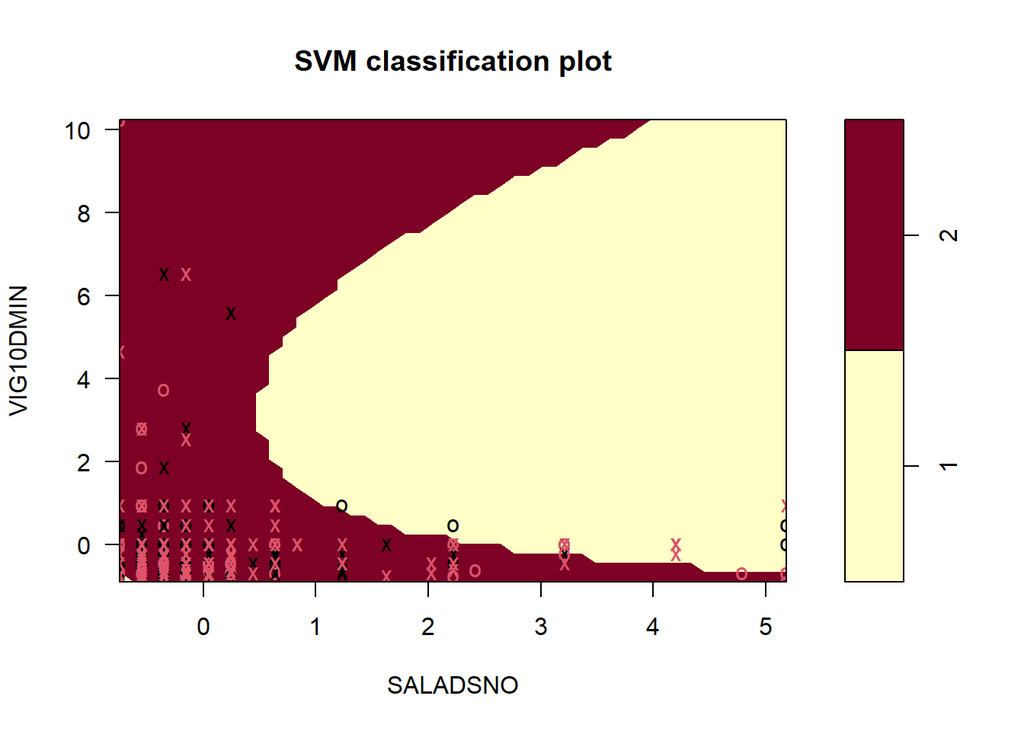

```r
plot(svmdiabetes_poly3, train, VIG10DMIN ~ SALADSNO)
```

This is an intuitive plot. Having more salads might lead to less blood sugar.